# Indicadores por madurez de la compañia y área del negocio

Exploraremos como es que el nivel de madurez influyen en la selección de KPIs. Distinguiremos entre indicadores "Lead" y "Lag" y ahondaremos en indicadores por área de negocio.

## Objetivo

- Entender como la madurez de la compañia afecta el enfoque de KPIs.
- Distinguir entre indicadores Lead y Lag.
- Aplicar este conocimiento en un caso de estudio para elegir KPIs apropiados basados en el nivel de madurez de la compañia y la disponibilidad de datos.

**Referencias:** Para una mejor comprensión visiten los siguientes vinculos:

- [Ladder of Proof](https://medium.com/@nfx/the-ladder-of-proof-56254ddd675f) por NFX, ayuda a entender a las Startups los pasos necesarios para probar que su modelo de negocio es atractivo.
- [Investopedia - Seed Capital](https://www.investopedia.com/terms/s/seedcapital.asp)
- [Forbes - KPIs](https://www.forbes.com/councils/theyec/2023/06/29/11-key-performance-indicators-your-business-should-be-tracking-and-why/)
- [Roman Pichler - How to Choose the Right KPIs](https://romanpichler.medium.com/how-to-choose-the-right-kpis-5f7957ed5ef6)

## Niveles de madures en la empresa y enfoque en KPIs

Los negocios atraviesan diversas etapas de crecimiento, cada una con sus propios desafíos y oportunidades. Para navegar con éxito en este camino, es fundamental seleccionar los indicadores clave de desempeño (KPIs) más adecuados. Estos indicadores nos permiten medir el progreso hacia nuestros objetivos y tomar decisiones estratégicas basadas en datos. **Sin embargo, es crucial reconocer que los KPIs son solo una parte de la ecuación.** Si bien son esenciales para monitorear el rendimiento general del negocio, no proporcionan una visión completa de la salud de la organización. Es necesario complementar los KPIs con otros indicadores y análisis cualitativos para obtener una comprensión más profunda de los factores que influyen en el éxito.

### 1. Etapa pre-semilla y semilla (pre-seed y seed).

- **Enfoque:** Esta etapa es para probar el concepto inicial, desarrollar el producto y ganar los primeros usuarios o clientes.
- **KPIs típicos:**
  - **User Engagement:** Mide la interacción del usuario con el producto, crucial para refinar la experiencia del usuario. La formula depende completamente del producto, pero comunmente puede encontrarse como tiempo promedio en la aplicación por usuario, click through rate, returning rate, etc...
  - **Retroalimentaciones de Early Adopter:** Insights cualitativos de usuarios iniciales que guian el desarrollo del producto.
  - **Monthly Active Users (MAU):** Métrica vital para medir la tracción inicial y la retención de los usuarios.
    - Formula: $\text{MAU} = \text{Unique Users per Month}$
  - **Burn Rate:** Tasa a la cual la compañia se gasta la inversión para financiar la idea antes de generar flujo de caja positivo de las operaciones.
    - Formula: $\text{Burn Rate} = \frac{\text{Dinero gastado a traves del periodo}}{\text{Periodo de tiempo}}$
  - **Cash Runway:** Tiempo (normalmente mencionado en meses) que tienes de vida como startup antes de que se le acabe el dinero. Esta métrica es importante por que te ayuda a seguir tu progreso y el tiempo que tienes para alcanzar a ser rentable.
    - Formula: $\text{Cash Runway} = \frac{\text{Capital}}{\text{Burn Rate}}$

### 2. Series A a C

- **Enfoque:** Las compañias en esta etapa están escalando las operaciones, expandiendo el mercado, y construyendo la linea de productos.
- **KPIs típicos:**
  - **Customer Acquisition Cost (CAC):** Costos asociados con convencer al cliente para adquirir el producto o servicio. Crucial para etender la escabilidad de los esfuerzos de venta.
    - Formula: $\text{CAC} = \frac{\text{Gastos totales de Marketing y Ventas}}{\text{Número de nuevos clientes adquiridos}}$
  - **Customer Lifetime Value (CLTV):** Predice el revenue total que un negocio puede esperar de manera razonable de un cliente a traves de la relación comercial que tenga con el negocio.
    - Formula: $\text{CLTV} = \frac{\text{Average Revenue per User (ARPU)} \times \text{Gross Margin}}{\text{Churn Rate}}$
  - **Tasa de crecimiento de ingresos:** Indica el ritmo al cual el ingreso de la compañía esta creciento, ayudando a medir el éxito de las estrategias de ventas y marketing.
    - Formula: $\text{Tasa de crecimiento de ingresos} = \frac{\text{Ingresos del periodo actual}}{\text{Ingresos del periodo pasado}} - 1$
  - **Churn Rate:** Mide la tasa a la cual los clientes dejan de tener una relación comercial con el negocio. Importante para entender la retención de los clientes.
    - Formula: $\text{Churn Rate} = \frac{\text{Numero de clientes perdidos en el periodo}}{\text{Clientes que comenzaron al inicio del periodo + Clientes adquiridos en el periodo}}$

### 3. Compañias maduras o independientes de inversión

- **Enfoque:** El enfoque cambia a sostenibilidad, eficiencia y maximizar el valor para los accionistas o dueños.
- **KPIs típicos:**
  - **Net Promoter Score (NPS):** Refleja la satisfacción y lealtad de los clientes. Crucial para negocios maduros enfocados en mantener o aumentar el número de sus clientes.
    - Formula: $\text{NPS} = (\text{% Promotores (9 o 10)} - \text{% Detractores (6 o menos)}) \times 100$
  - **Market Share:** Indica el porcentaje de las ventas de una industria que controla una determinada empresa, mostrando una posición competitiva.
    - Formula: $\text{Market Share} = \frac{\text{Ventas de la compañia}}{\text{Ventas totales de la industria}} \times 100$
  - **EBITDA:** Provides insight into profitability before the effects of interest, taxes, depreciation, and amortization.
    - Formula: $\text{EBITDA} = \text{Ingresos} - \text{Costos y gastos (excluyendo impuestos, intereses, depreciación, y amortización)}$
  - **Return on Assets (ROA):** Indica que tan eficiente una compañía puede administrar sus actuvis para producir ganancias durante un periodo.
    - Formula: $\text{ROA} = \frac{\text{Ingreso neto}}{\text{Activos totales}}$

Esta sección marca la importancia de alinear los KPIs con la etapa de desarrollo de la empresa para asegurar que reflejan y apoyan adecuacuadamente los objetivos de la empresa y sus necesidades operacionales.

## Indicadores Lead y Lag

Lead y Lag son dos tipos de indicadores usados para medir el desempeño. Sirven para propositos distintos y proveen conclusiones a diferentes tiempos del ciclo de la empresa.

**Referencias:** [Investopedia - Lead and Lag Indicators](https://www.investopedia.com/ask/answers/what-are-leading-lagging-and-coincident-indicators/)

### Indicadores Lead

- **Definición:** Indicadores Lead son medidas predictivas que mandan señales de eventos futuros y son útiles para influir en el cambio. Por lo general, ofrecen datos en tiempo real que pueden predecir el resultado de un proceso.
- **Ejemplos:**
  - **Customer Satisfaction (CSAT):** Puede indicar retención y recurrencia de los usuarios. Indicador Lead especificamente para áreas como ventas, producto o retención de clientes.
  - **Trafico del sitio web:** Puede indicar ventas futuras de la empresa.
  - **Horas de etrenamiento de empleados:** Correlacionada positivamente con mejoras en la calidad de producción o entrega de servicio.
- **Ventajas:** Teniendo vista al futuro, los indicadores Lead pueden ayudar a directivos a hacer ajusted proactivos antes de que los resultados Lag sean aparentes.

### Indicadores Lag

- **Definición:** Los indicadores lag miden el resultado de los procesos, mostrando el impacto de las acciones pasadas al final del periodo. Estan enfocadas en resultados.
- **Ejemplos:**
  - **Ganancia trimestral:** Refleja el desempeño financiero del pasado.
  - **Customer Satisfaction (CSAT):** Es obtenido despues de que el cliente interactua con el producto o servicio.
- **Ventajas:** Son útiles para declarar objetivos y evaluaciones de desempeño. Proveen datos que son certeros y fáciles de recolectar y entender.

Entender la diferencia entre indicadores Lead y Lag, y como pueden ser aplicados de manera estrategica en el contexto de las actividades operacionales de una empresa, es crucial para una administración y toma de decisión efectiva.

## Caso práctico: OptiTech Solutions

**Antecedentes:** OptiTech Solutions es una empresa de tecnología en expansión que se especializa en la implementación de soluciones de Inteligencia Artificial para pequeñas empresas. Desde su fundación hace cinco años, OptiTech ha progresado desde las fases iniciales de financiamiento hasta la etapa de crecimiento acelerado. Actualmente, la empresa se está preparando para una ronda de financiación Serie B, con el objetivo de ampliar su presencia en el mercado y mejorar las funcionalidades de sus productos.

**Desafío:** El reto principal de OptiTech Solutions es fortalecer su toma de decisiones estratégicas para atraer inversionistas y asegurar un crecimiento sostenible. Para esto, el equipo directivo pretende optimizar sus Indicadores Clave de Desempeño (KPIs) relacionados con la adquisición de clientes y su satisfacción, facilitando así decisiones más informadas y adaptativas frente a las exigencias del mercado.

**Datos disponibles:** Descripción de los datos

- Date: Mes y año de registro.
- Marketing_Expenditure: Fondos dedicados a Marketing.
- Web_Traffic: Numero de visitas en la página.
- New_Customers: Clientes nuevos adquiridos mensualmente.
- Beginning_Customers: Clientes totales al inicio del mes.
- Monthly_Revenue: Ingreso mensual.
- Employee_Training_Hours: Horas dedicadas al entrenamiento de empleados al mes.
- Total_Customer_Respondents: Clientes que contestaron la encuesta CSAT.
- High_Customer_Score_Respondents: Clientes que dieron una calificación de 4 o 5 al CSAT.
- Total_Employee_Respondents: Empleados que contestaron el eNPS.
- Promoters_Employee_Score_Respondents: Empleados que dieron una calificación de 9 o 10 al eNPS.
- Detractors_Employee_Score_Respondents: Empleados que dieron una calificación de 6 o menos al eNPS.

**Su actividad:** Como consultores, su grupo tiene la tarea de:

1. Revisar la trayectoria de crecimiento de la empresa: NO HACERLO
   - Analizar los datos históricos de ingresos y gastos de marketing para evaluar la salud financiera y los patrones de crecimiento de OptiTech Solutions.
   - Evaluar el tráfico web y las tendencias de adquisición de clientes para inferir el alcance del mercado y la visibilidad de la marca.
1. Definir indicadores clave de rendimiento (KPI):
   - Determinar los KPIs más cruciales que correspondan con la fase actual de desarrollo de la empresa y sus metas estratégicas, incluyendo métricas financieras y no financieras.
   - Proponer Lead KPIs que proporcionen información predictiva para los ajustes operativos y Lag KPIs para la planificación estratégica.
1. Cálculo de métricas:
   - Calcule los KPI seleccionados utilizando los datos históricos proporcionados. Utilice Python y pandas en su Jupyter Notebook para la manipulación y el cálculo de datos.
   - Analice las tendencias y los patrones de estas métricas para proporcionar información sobre la eficacia operativa y la alineación estratégica.
1. Establecer parámetros de referencia (benchmarks):
   - Investigar los estándares de la industria y los parámetros de referencia de empresas tecnológicas similares en etapas comparables de crecimiento.
   - Comparar el desempeño de OptiTech con estos parámetros de referencia para identificar áreas de fortaleza y oportunidades de mejora.
1. Presentar los hallazgos:
   - Resume el análisis, los hallazgos y las recomendaciones.
   - Resalta cómo los KPIs propuestos pueden ayudar a OptiTech a lograr sus objetivos estratégicos y prepararse de manera eficaz para la ronda de financiación de la Serie B.

```python
## KPI´S:
    # - CSAT ( High_Customer_Score_Respondents / Total_Customer_Respondents) = satisfacción de clientes
    # - el CAC para ver cuanto me cuesta traer un nuevo cliente (escalabilidad)
```

[output not shown]

```python
import pandas as pd
```

```python
df = pd.read_csv('optitech_solutions_data.csv')
```

```python
df.head()
```

|  | Date | Marketing_Expenditure | Web_Traffic | New_Customers | Beginning_Customers | Monthly_Revenue | Employee_Training_Hours | Total_Customer_Respondents | High_Customer_Score_Respondents | Total_Employee_Respondents | Promoters_Employee_Score_Respondents | Detractors_Employee_Score_Respondents |
| --- | --- | --- | --- | --- | --- | --- | --- | --- | --- | --- | --- | --- |
| 0 | 2019-01-31 | 14542 | 23452 | 71 | 71 | 65003 | 115 | 232 | 63 | 85 | 17 | 5 |
| 1 | 2019-02-28 | 29014 | 25523 | 16 | 79 | 32044 | 137 | 285 | 122 | 75 | 26 | 4 |
| 2 | 2019-03-31 | 27571 | 15227 | 44 | 124 | 57586 | 128 | 258 | 116 | 57 | 21 | 3 |
| 3 | 2019-04-30 | 27316 | 13223 | 17 | 141 | 66405 | 101 | 214 | 91 | 99 | 36 | 7 |
| 4 | 2019-05-31 | 25355 | 29371 | 95 | 228 | 95995 | 113 | 235 | 93 | 77 | 25 | 5 |

```python
df.describe()
```

|  | Marketing_Expenditure | Web_Traffic | New_Customers | Beginning_Customers | Monthly_Revenue | Employee_Training_Hours | Total_Customer_Respondents | High_Customer_Score_Respondents | Total_Employee_Respondents | Promoters_Employee_Score_Respondents | Detractors_Employee_Score_Respondents |
| --- | --- | --- | --- | --- | --- | --- | --- | --- | --- | --- | --- |
| count | 60.000000 | 60.000000 | 60.000000 | 60.000000 | 6.000000e+01 | 60.000000 | 60.000000 | 60.000000 | 60.000000 | 60.000000 | 60.000000 |
| mean | 23770.650000 | 23998.700000 | 48.316667 | 1299.083333 | 5.325228e+05 | 123.166667 | 232.050000 | 99.533333 | 75.133333 | 26.233333 | 4.566667 |
| std | 3302.653175 | 9221.395511 | 32.123433 | 769.860328 | 3.503077e+05 | 20.818153 | 46.027046 | 22.392089 | 14.611891 | 5.315046 | 0.963163 |
| min | 14542.000000 | 10000.000000 | 10.000000 | 71.000000 | 3.204400e+04 | 83.000000 | 150.000000 | 59.000000 | 50.000000 | 17.000000 | 3.000000 |
| 25% | 21308.250000 | 18215.250000 | 22.750000 | 638.250000 | 2.652680e+05 | 104.750000 | 196.000000 | 84.750000 | 62.000000 | 22.000000 | 4.000000 |
| 50% | 24019.000000 | 23090.000000 | 41.500000 | 1264.500000 | 4.950735e+05 | 122.500000 | 237.000000 | 98.000000 | 76.500000 | 26.000000 | 4.500000 |
| 75% | 25557.000000 | 28350.500000 | 66.250000 | 1849.500000 | 7.556240e+05 | 138.000000 | 272.000000 | 117.500000 | 85.000000 | 29.250000 | 5.000000 |
| max | 29950.000000 | 51420.000000 | 134.000000 | 2727.000000 | 1.674471e+06 | 182.000000 | 298.000000 | 142.000000 | 99.000000 | 39.000000 | 7.000000 |

```python
df['cac'] = df['Marketing_Expenditure'] / df['New_Customers']
```

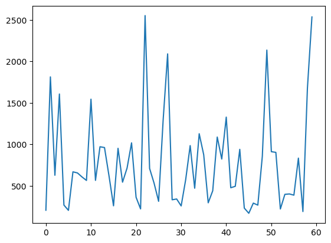

```python
df['cac'].plot()
```

```python
df['csat'] = df['High_Customer_Score_Respondents'] / df['Total_Customer_Respondents']
```

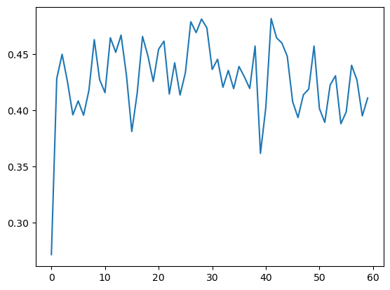

```python
df['csat'].plot()
```

Análisis

Un CSAT adecuado debería estar en 0.65, nosotros estamos en 0.45, lo que indica que estamos por debajo del nivel deseado y es necesario mejorarlo. En cuanto al CAC, su benchmark varía según la empresa. Es muy importante compararlo con otras empresas y con el valor del cliente. Según la gráfica el costo de adquisición de nuevos clientes, por lo que su nuevo objetivo sería reducirlo a $800 pesos por cliente adquirido.